# **Popularitätsprognose von Spotify-Songs** | EMLP-Projekt

Veit Starost, Jonas Egeler

## Einleitung

Im Jahr 2020 ist Spotify mit mehr als 60 Millionen gelisteten Musiktiteln und über 320 Millionen aktiven Nutzern der größte Audio-Stremaing-Onlinedienst der Welt [https://www.spotify.com/]. Im Durchschnitt streamt jeder Nutzer pro Tag etwas mehr als eine Stunde Musik [https://de.statista.com/]. Damit ist klar, dass Spotify im Laufe der Zeit einen gigantischen Vorrat an Nutzungsdaten aufbauen konnte. Mit der Anzahl der Wiedergaben und einer Gewichtung, die berücksichtigt, wie lange die Wiedergaben in der Zeit zurückliegen, berechnet Spotify für jeden Track einen Popularity-Index, der auf einer Skala von 0 (unpopulär) bis 100 (populär) angibt, wie beliebt der Track bei den Nutzern ist: $popularity = f(n_{clicks}, t_{clicks})\,\,\,\in[0,100]$.  
Über die Web API [https://developer.spotify.com/documentation/web-api/] können Metadaten, Signalanalyse-Parameter, sowie der Popularity-Index der gelisteten Tracks abgerufen werden. Der vorliegenden Datensatz beinhaltet Daten zu mehr als 170 000 Tracks, die über die Web API gesammelt wurden.  
Im Rahmen des EMLP-Projektes soll untersucht werden, welche Faktoren die Popularität eines Tracks beeinflussen. Projektziel ist es, ein Regressions-Modell zu entwickeln, dass die Popularität eines Tracks auf Basis der im Datensatz erfassten Metadaten und Signalanalyse-Parametern möglichst genau vorhersagt. In diesem Projektbericht wird die Umsetzung der Datenanalyse mit Python detailliert beschrieben.

## Pre-Processing

### Erklärung zum Datensatz

[output not shown]

### Erste Untersuchung des Datensatzes

```python
df.info() # Allgemeine Infos zum Datensatz
```

```
<class 'pandas.core.frame.DataFrame'>
RangeIndex: 170653 entries, 0 to 170652
Data columns (total 19 columns):
valence             170653 non-null float64
year                170653 non-null int64
acousticness        170653 non-null float64
artists             170653 non-null object
danceability        170653 non-null float64
duration_ms         170653 non-null int64
energy              170653 non-null float64
explicit            170653 non-null int64
id                  170653 non-null object
instrumentalness    170653 non-null float64
key                 170653 non-null int64
liveness            170653 non-null float64
loudness            170653 non-null float64
mode                170653 non-null int64
name                170653 non-null object
popularity          170653 non-null int64
release_date        170653 non-null object
speechiness         170653 non-null float64
tempo               170653 non-null float64
dtypes: float64(9), int64(6), object(4)
memory usage: 24.7+ MB
```

```python
df.sort_values(by='popularity', ascending = False).head(3) # Die drei populärsten Einträge werden ausgegeben
```

|  | valence | year | acousticness | artists | danceability | duration_ms | energy | explicit | id | instrumentalness | key | liveness | loudness | mode | name | popularity | release_date | speechiness | tempo |
| --- | --- | --- | --- | --- | --- | --- | --- | --- | --- | --- | --- | --- | --- | --- | --- | --- | --- | --- | --- |
| 19611 | 0.145 | 2020 | 0.4010 | ['Bad Bunny', 'Jhay Cortez'] | 0.731 | 205090 | 0.573 | 1 | 47EiUVwUp4C9fGccaPuUCS | 0.000052 | 4 | 0.1130 | -10.059 | 0 | Dakiti | 100 | 2020-10-30 | 0.0544 | 109.928 |
| 19606 | 0.756 | 2020 | 0.2210 | ['24kGoldn', 'iann dior'] | 0.700 | 140526 | 0.722 | 1 | 3tjFYV6RSFtuktYl3ZtYcq | 0.000000 | 7 | 0.2720 | -3.558 | 0 | Mood (feat. iann dior) | 99 | 2020-07-24 | 0.0369 | 90.989 |
| 19618 | 0.737 | 2020 | 0.0112 | ['BTS'] | 0.746 | 199054 | 0.765 | 0 | 0t1kP63rueHleOhQkYSXFY | 0.000000 | 6 | 0.0936 | -4.410 | 0 | Dynamite | 97 | 2020-08-28 | 0.0993 | 114.044 |

### Bereinigung des Datensatzes

```python
df.duration_ms = df.duration_ms/60000 # Umrechnung von ms in min
df = df.rename(columns={'duration_ms' : 'duration_min'}) # Umbenennen der Spalte 'duration_ms' in 'duration_min'
df = pd.DataFrame(df[df['duration_min'] < 12]) # Behalte alle Tracks mit <= 12 min Dauer
#df.head()
```

```python
df = df.drop(labels = ['release_date', 'id'], axis = 1) # 'Release_date' ist in unerschiedlicher Genauigkeit angegeben und doppelt sich mit 'year' -> drop!
# 'id' wird ebenfalls gedroppt, da uninformativ
```

### Datenvisualisierung

#### Histogramme

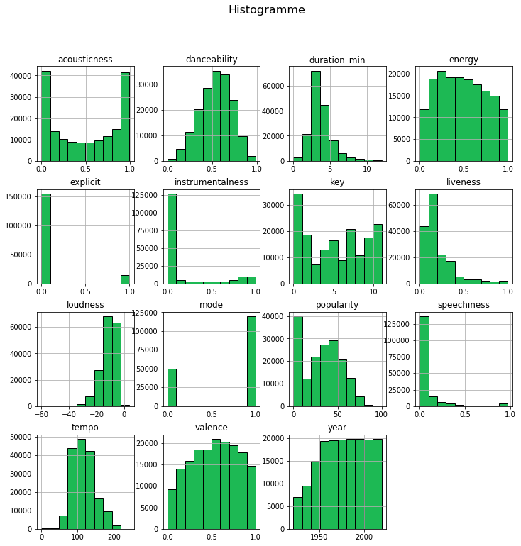

```python
g = df_num.hist(figsize = (12, 12), color = '#1DB954', ec = "black") # Zeigt die Verteilung der Werte; #1DB954 für Spotify-Grün
plt.suptitle('Histogramme', size = 16)
plt.show()
```

#### Korrelationsmatrix

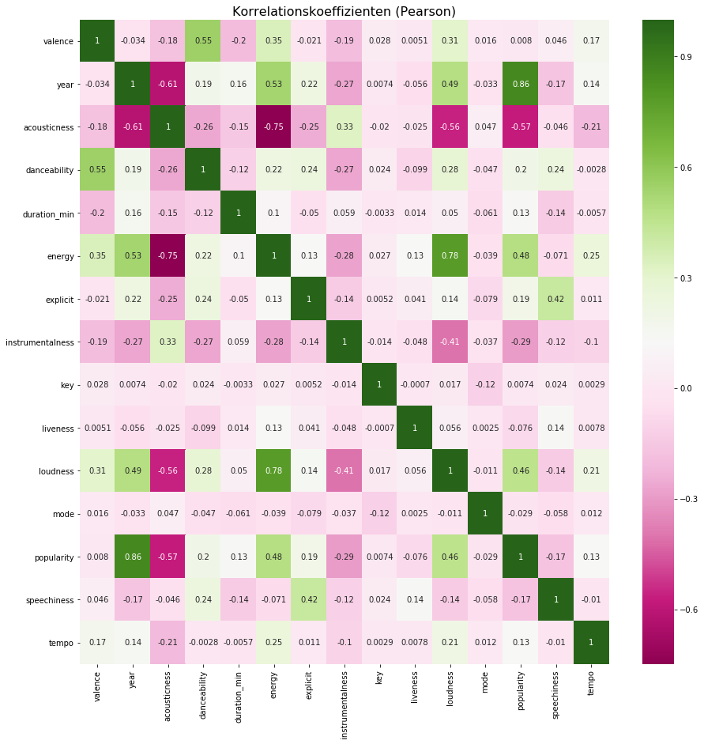

```python
plt.figure(figsize = (15, 15))
ax = plt.axes()
sns.heatmap(df_num.corr(), annot = True, cmap = 'PiYG', ax = ax)
ax.set_title('Korrelationskoeffizienten (Pearson)', size = 16)
plt.show()
```

#### Pairplot

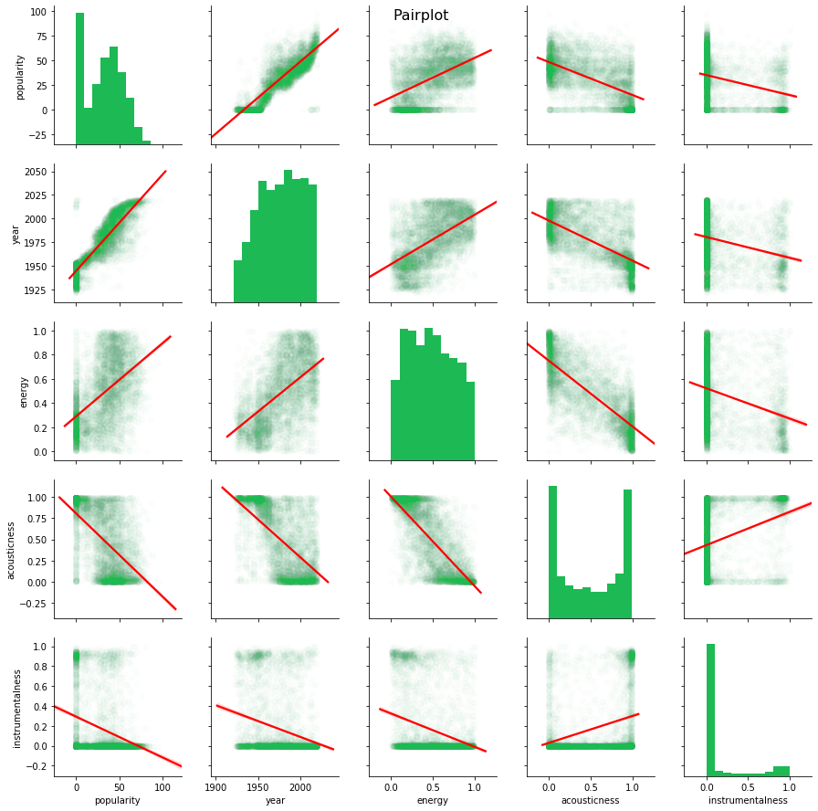

```python
plt.figure(figsize = (25, 25))
g = sns.pairplot(df_num[['popularity','year','energy','acousticness','instrumentalness']].sample(5000), kind = 'reg', plot_kws = {'line_kws':{'color':'red'}, 'scatter_kws': {'color':'#1DB954','alpha': 0.01}}, diag_kws = {'color':'#1DB954'})
g.fig.suptitle('Pairplot', size = 16)
plt.show()
```

## String-Daten: Target Encoding

### Künstler Popularity-Index

Für die Berechnung des Künstler Popularity-Index wird für jeden Künstler der Mittelwert der Popularität seiner Tracks gebildet.

```python
df_art = pd.concat([df_str['artists'], df_num['popularity']], axis = 1) # Neuer df mit artist und popularity
```

```python
df_art['popularity'] = df_art['popularity'].groupby([df_art['artists']]).transform('mean') # Ersetzen der popularity mit mittlerer popularity des artist
df_art = df_art.rename(columns={'popularity' : 'artists_popularity'}) # Umbenennen der Spalte 'popularity' in 'artist_popularity'
df_art = pd.concat([df_art, df_num['popularity']], axis = 1) # Hinzufügen der 'popularity' für Plot
```

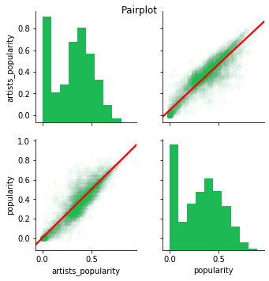

```python
plt.figure(figsize=(15, 15))
g = sns.pairplot(df_art.sample(5000), kind = 'reg', plot_kws={'line_kws':{'color':'red'}, 'scatter_kws': {'color':'#1DB954','alpha': 0.01}}, diag_kws={'color':'#1DB954'})
g.fig.suptitle('Pairplot')
plt.show()
```

```python
df_art.sort_values(by = 'artists_popularity', ascending = False).head(n = 10)
```

|  | artists | artists_popularity | popularity |
| --- | --- | --- | --- |
| 19611 | ['Bad Bunny', 'Jhay Cortez'] | 1.00 | 1.00 |
| 19606 | ['24kGoldn', 'iann dior'] | 0.99 | 0.99 |
| 19608 | ['Cardi B', 'Megan Thee Stallion'] | 0.96 | 0.96 |
| 19620 | ['Justin Bieber', 'benny blanco'] | 0.95 | 0.95 |
| 19720 | ['Sech', 'Daddy Yankee', 'J Balvin', 'ROSALÍA'... | 0.94 | 0.94 |
| 19655 | ['Joel Corry', 'MNEK'] | 0.94 | 0.94 |
| 19609 | ['Drake', 'Lil Durk'] | 0.93 | 0.93 |
| 19621 | ['Ritt Momney'] | 0.93 | 0.93 |
| 19672 | ['J Balvin', 'Tainy', 'Dua Lipa', 'Bad Bunny'] | 0.92 | 0.92 |
| 38452 | ['Manuel Turizo', 'Rauw Alejandro', 'Myke Towe... | 0.92 | 0.92 |

### Titel Popularity-Index

Für die Berechnung des Titel Popularity-Index werden die einzenlnen Titel-Strings zunächst anhand der Leerzeichen in einzelne Wörter getrennt. Für jedes Wort wird der Mittelwert seiner Popularität anhand aller seiner *'popularity'*-Werte berechnet. Um den finalen Index zu erhalten werden für jeden Titel die mittleren Popularitäten seiner Bestandteile addiert und durch die Anzahl der Bestandteile dividiert.

```python
df_nam = pd.concat([df_str['name'], df_num['popularity']], axis = 1) # Neuer df mit name und popularity
```

```python
df_nam['name'] = df_nam.name.astype(str) # Umwandlung in String-Format
df_nam = df_nam.assign(name = df_nam.name.str.split()) # name-String wird anhand von Leerzeichen in Liste getrennt
df_nam['name'] = df_nam['name'].map(lambda a: tuple(a)) # Umwandlung in Tupel
#df_nam.head()
```

```python
df_par = df_nam.explode('name') # Auftrennen des df_nam in einzelne name-Bestandteile und zugehöriger popularity
#df_par.head(n=10)
```

```python
df_par['popularity'] = df_par['popularity'].groupby([df_par['name']]).transform('mean') # Ersetzen der popularity mit mittlerer popularity des name-Bestandteil
df_par = df_par.assign(count = df_par['popularity'].groupby([df_par['name']]).transform('count')) # Zähle Erscheinungen des Namensbestandteils
df_par = df_par.rename(columns={'popularity' : 'name_part_popularity'}) # Umbenennen der Spalte 'popularity' in 'name_part_popularity'
df_par = df_par.drop_duplicates(subset='name') # Entfernen der Duplikate
```

```python
df_par.sort_values(by = 'name_part_popularity', ascending = False).head(n = 15)
```

|  | name | name_part_popularity | count |
| --- | --- | --- | --- |
| 19611 | Dakiti | 1.000000 | 1 |
| 19608 | WAP | 0.960000 | 1 |
| 19620 | benny | 0.950000 | 1 |
| 19620 | blanco) | 0.950000 | 1 |
| 19623 | broke | 0.950000 | 1 |
| 19655 | MNEK) | 0.940000 | 1 |
| 19624 | Therefore | 0.930000 | 1 |
| 19672 | DIA | 0.920000 | 1 |
| 19672 | (ONE | 0.920000 | 1 |
| 19672 | DAY) | 0.920000 | 1 |
| 38426 | Guaynaa) | 0.920000 | 1 |
| 38427 | Curiosidad | 0.920000 | 1 |
| 19628 | POPSTAR | 0.910000 | 1 |
| 38435 | BICHOTA | 0.910000 | 1 |
| 19646 | Hawái | 0.903333 | 3 |

```python
#Hier wird der Titel-Popularitätsindex berechnet und in ein Excel-File exportiert, dass schnell importiert werden kann (Runtime ca. 2h!)
#def name_popularity(x, df_nam, df_par):
#    pop = 0
#    n = 0
#    for part in x:
#        pop = pop + df_par['name_part_popularity'][df_par['name'] == part].values
#        n += 1
#    return str(pop/n)
#
#df_nam['name'] = df_nam['name'].apply(lambda x: name_popularity(x, df_nam, df_par))
#df_nam.to_excel("title_popularity.xlsx")
```

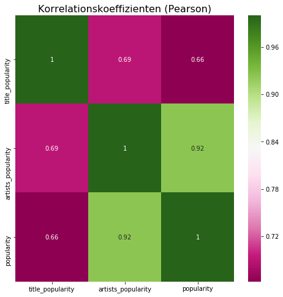

```python
plt.figure(figsize = (8, 8))
ax = plt.axes()
sns.heatmap(df_prepro[['title_popularity', 'artists_popularity', 'popularity']].corr(), annot = True, cmap = 'PiYG', ax = ax)
ax.set_title('Korrelationskoeffizienten (Pearson)', size = 16)
plt.show()
```

## Machine Learning

### Daten als NumPy-Array

Der Datensatz wird in Inputdaten $X$ und Targetdaten $y$ aufgeteilt, welche in Form von NumPy-Arrays gespeichert werden.

### Split in Trainings- und Testdaten

Input- und Trainingsdaten werden jeweils in 80 % Trainingsdaten und 20 % Testdaten aufgeteilt.

Die Funktion *print_metrics()* wird definiert. Bei Aufruf der Funktion werden die Qualitätsmetriken $RMSE$ (root mean squared error) und $R^2$ (Anteil an Varianz der Daten, der durch Modell erklärt wird) über einen Vergleich von Test-Daten und Vorhersagen berechnet und in die Konsole geschrieben.

```python
# Funktion für die Evaluation der Vorhersagen
def print_metrics(y_true, preds, model_name=None):

    if model_name == None:
        print('RMSE: ', format(np.sqrt(mean_squared_error(y_true, preds))))
        print('R-Squared: ', format(r2_score(y_true, preds)))
        #print('\n\n')

    else:
        print('RMSE für ' + model_name + ' :' , format(np.sqrt(mean_squared_error(y_true, preds))))
        print('R-Squared für ' + model_name + ' :', format(r2_score(y_true, preds)))
        #print('\n\n')
```

### Multiple lineare Regression

Das lineare Regressionsmodell ist das einfachste zu testende Modell, bei dem der Target-Wert über eine möglichst optimale Linearkombiation der Input-Werte gebildet wird.

```python
# Ausgabe der Fit-Koeffizienten a*valence+b*year+c*acousticness...
coeff_df = pd.DataFrame(mlinear_regression.coef_, df_prepro.drop(['popularity','artists_popularity', 'title_popularity'], axis=1).columns, columns=['Coefficient'])
coeff_df
```

|  | Coefficient |
| --- | --- |
| valence | 0.006787 |
| year | 0.659634 |
| acousticness | -0.042181 |
| danceability | 0.024186 |
| duration_min | 0.000019 |
| energy | -0.018124 |
| explicit | 0.010314 |
| instrumentalness | -0.041874 |
| key | -0.000076 |
| liveness | -0.029956 |
| loudness | 0.013288 |
| mode | -0.002501 |
| speechiness | -0.075424 |
| tempo | 0.005273 |

|  | $RMSE$ | $R^2$ |
| --- | --- | --- |
| Lineare Regression | 0,106 | 76,1% |

### Polynomische Regression

Bei der polynomischen Regression wird eine möglichst optimale Linearkombination von polynomischen Features gesucht. Dazu werden zunächst mit *PolynomialFeatures()* die Potenzen der Input-Werte bis zum Grad $n$ berechnet. Anschließend wird ein lineares Modell mit den polynomischen Features gefitted.

Die polynomische Regression ist sehr zeitaufwändig für Ordnungen > 4. Für $n=4$ ist die Vorhersagegenauigkeit:

|  | $RMSE$ | $R^2$ |
| --- | --- | --- |
| Polynomische Regression ($n=4$) | 0,099 | 79,4% |

### KNeighbors Regression

Bei dem KNeighbors Modell wird der Target-Wert der Test-Daten auf Basis eines (mit der Distanz) gewichteten Mittelwerts der Target-Werte der Trainings-Daten in der unmittelbaren Umgebung der Test-Daten ermittelt (Prinzip: Wahrscheinlichkeitsdichteschätzung).

|  | $RMSE$ | $R^2$ |
| --- | --- | --- |
| KNeighbors | 0,110 | 74,6% |

#### Grid Search

Als Grid Search wird das ausprobieren von verschiedenen Einstellparametern eines ML prozesses bezeichnet um das Ergebniss zu optimieren. Dabei können alle möglichen Kombinationen von den gegebenen Parametern ausprobiert werden, oder nur eine zufällige auswahl der Kombinationen.

Mit der Funktion *GridSearchCV()* werden unterschiedliche Anzahlen der nächsten Nachbarn ($n=5,10,15,30$) getestet.

|  | $RMSE$ | $R^2$ |
| --- | --- | --- |
| KNeighbors (GSCV) | 0,104 | 77,0% |

### Support Vector Machine

Eine Support Vector Machine unterteilt eine Menge von Objekten so in Klassen, dass um die Klassengrenzen herum ein möglichst breiter Bereich frei von Objekten bleibt; sie ist ein sogenannter Large Margin Classifier (dt. „Breiter-Rand-Klassifikator“)[https://de.wikipedia.org/wiki/Support_Vector_Machine].

|  | $RMSE$ | $R^2$ |
| --- | --- | --- |
| SVR | 0,100 | 78,8% |

#### Grid Search

Mit *RandomizedSearchCV()* werden unterschiedliche Parameter-Konfiguarationen für das Modell getestet. Indem man nur einige zufällige Kombinationen der Parameter testet kann die Rechenzeit stark verringert werden. Dadurch kann es allerdings passieren, dass die gefundene beste Lösung nicht die insgesammt beste Kombination ist.

Das SVR-Modell mit '*radial basis function*' (*rbf*) kernel und einem *C*-Wert von 5 hat die folgende Vorhersagegenauigkeit:

|  | $RMSE$ | $R^2$ |
| --- | --- | --- |
| SVR (RSCV) | 0,100 | 79,0% |

### Neuronales Netz

Ein neuronales Netz ist eine ML-Struktur, die sich am Aufbau des Gehirns orientiert. Die Abbildung von Input- auf Target-Daten findet über künstliche Neuronen, z. B. Perzeptronen, also lineare Funktionen mit nicht-linearer Aktivierungsfunktion am Ausgang, statt, die über mehrere Schichten hinweg miteinander verschaltet sind. Beim Lernprozess werden die Gewichte der Verschaltungen iterativ über den sog. Backpropagation-Algorithmus so verändert, dass die Loss-Funktion (Unterschied zwischen Input- und Target) minimiert wird.

Die Verschaltungen in neuronalen Netzen sind sehr komplex und können nicht einfach visualisiert werden. Es gibt allerding verschiedene Ansätze, die Ergebnisse solcher undurchsichtigen Modelle zu konkretisieren und zum Teil wieder vorstellbar zu machen. Hierfür wird das Framework *LIME* verwendet.

Das neuronale Netz ohne Parametervariation durch Grid Search bringt folgende Vorhersagegenauigkeit:

|  | $RMSE$ | $R^2$ |
| --- | --- | --- |
| NN | 0,097 | 80,0% |

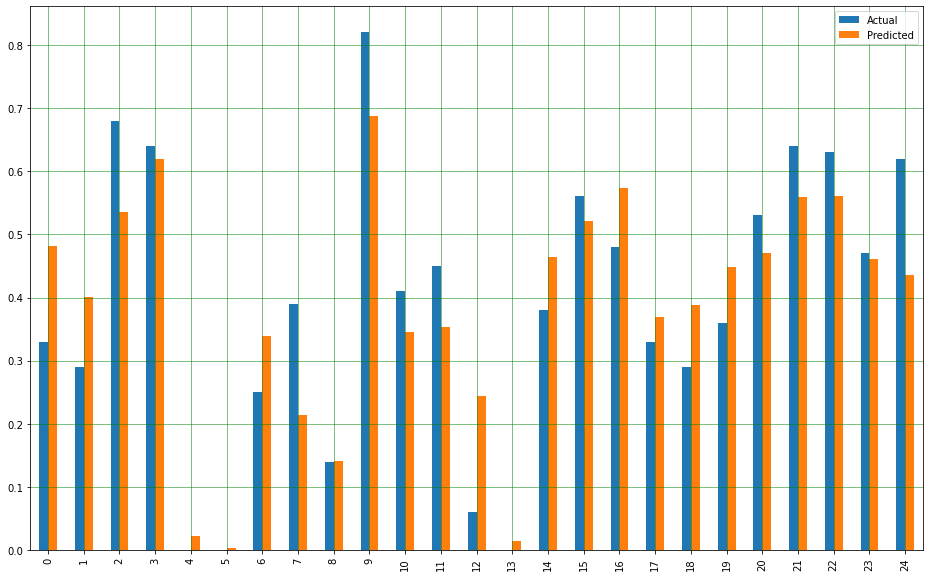

```python
df1 = df_result.head(25)
df1.plot(kind='bar',figsize=(16,10))
plt.grid(which='major', linestyle='-', linewidth='0.5', color='green')
plt.grid(which='minor', linestyle=':', linewidth='0.5', color='black')
plt.show()
```

#### Grid Search

Vor allem bei den neuronalen Netzen ist das Ausprobieren aller Möglichkeiten sehr zeitintensiv, weshalb hier die zufällige Auswahl verwendet wird. Dadurch kann es allerdings passieren, dass die gefundene beste Lösung nicht die insgesamt beste Kombination ist.

Das neuronale Netz mit Verbesserungsansatz durch Grid Search bringt diese Vorhersagegenauigkeit:

|  | $RMSE$ | $R^2$ |
| --- | --- | --- |
| NN (RSCV) | 0,097 | 80,1% |

[figure not shown]

```python
df1 = df_result.head(25)
df1.plot(kind='bar',figsize=(16,10))
plt.grid(which='major', linestyle='-', linewidth='0.5', color='green')
plt.grid(which='minor', linestyle=':', linewidth='0.5', color='black')
plt.show()
```

#### Feature Importance

Welche Features sind ausschlaggebend für die Popularitäts-Vorhersage?

Das Framework LIME kann für ein explizites Beispiel aus dem Testdatensatz aussagen, welche Features für die Entscheidung des ML Modells wichtig waren.

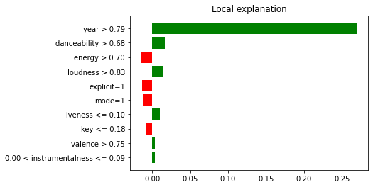

```python
%matplotlib inline
fig = exp.as_pyplot_figure();
```

```python
X_test_origi.iloc[i]
```

```
valence                           0.974
year                               2008
acousticness                      0.114
artists             ['Vampire Weekend']
danceability                      0.694
duration_min                   3.262217
energy                            0.711
explicit                              1
instrumentalness                0.00124
key                                   0
liveness                         0.0433
loudness                         -4.237
mode                                  1
name                       Oxford Comma
speechiness                      0.0517
tempo                           119.516
Name: 17382, dtype: object
```

### Decision Tree

Der Decision Tree wird wegen seiner Anschaulichkeit vor allem für Klasifizierungsprobleme angewandt, kann aber auch für Regressionsproblemen verwendet werden.

Die Darstellung eines Baumes ist bei Regressionsproblemen allerdings schwierig, da schnell eine hohe Anzahl von Knoten erreicht wird.

Der Decision Tree ohne Verbesserungsansatz durch Grid Search bringt folgende Vorhersagegenauigkeit:

|  | $RMSE$ | $R^2$ |
| --- | --- | --- |
| Tree | 0,134 | 62,0% |

#### Grid Search

Da ein Decision Tree relativ wenig Zeit zum Trainieren benötigt und es nur relativ wenige Parameter und Kombinationsmöglichkeiten gibt, kann hier die komplette Grid Search angewandt werden.

Der Decision Tree mit Verbesserungsansatz durch Grid Search bringt diese Vorhersagegenauigkeit:

|  | $RMSE$ | $R^2$ |
| --- | --- | --- |
| Tree (GSCV) | 0,097 | 80,3% |

Hier konnte durch das Grid Search eine deutliche Verbesserung erzielt werden, sowohl bei der Genauikkeit als auch bei dem Fehlerwert.

#### Feature Importance

Welche Features sind ausschlaggebend für die Popularitäts-Vorhersage?

Das Framework LIME kann für ein explizites Beispiel aus dem Testdatensatz aussagen welche Features für die Entscheidung des ML-Modells wichtig waren.

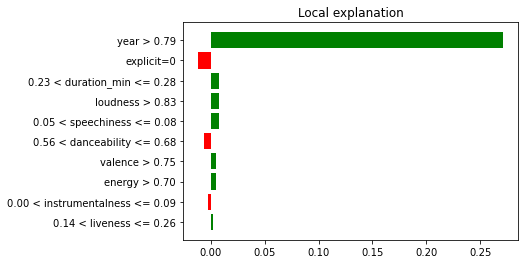

```python
%matplotlib inline
fig = exp.as_pyplot_figure();
```

```python
X_test_origi.iloc[i]
```

```
valence                                    0.801
year                                        2005
acousticness                               0.154
artists             ['Cardenales De Nuevo León']
danceability                               0.659
duration_min                            2.971333
energy                                     0.739
explicit                                       0
instrumentalness                         0.00027
key                                            2
liveness                                   0.243
loudness                                  -7.102
mode                                           1
name                          Amor De Unas Horas
speechiness                               0.0462
tempo                                    107.215
Name: 167539, dtype: object
```

## Vergleich und Zusammenfassung

|  | Lin. Reg. | Pol. Reg. | KNeighbours | SVR | NN | Decision Tree |
| --- | --- | --- | --- | --- | --- | --- |
| $R^2$ | 76,1% | 79,4% | 77,0% | 79,0% | 80,1% | 80,3% |
| $RMSE$ | 0,106 | 0,099 | 0,104 | 0,100 | 0,097 | 0,097 |